# PracticalHW1:DecisionTrees

2025-04-06

## Introduction

This homework will use decision trees to explore youth drug use using survey data from the [National Survey on Drug Use and Health](https://www.datafiles.samhsa.gov/dataset/national-survey-drug-use-and-health-2020-nsduh-2020-ds0001). The survey collects detailed information on respondents’ demographics, youth experiences, use of various drugs, and more. Because there are so many different data and categories available:

*Your task is to investigate factors that are correlated with youth drug use.*

In your models, you must include one example of each of the following problem types:

- binary classification (e.g. has or has not used cigarettes)
- multi-class classification (e.g. differentiate between seldom, sometimes, and frequent marijuana use)
- regression (e.g. number of days per year a person has used alcohol)

## Problem Framework

*Consider factors that are correlated with youth marijuana use to suggest implementations for school drug use programs*

Model Implementations:

- binary classification (has or has not used marijuana)
- multi-class classification (differentiate between seldom, sometimes, and frequent marijuana use)
- regression (average age first used marijuana)

## Data Cleaning and Exploration

```r
# load cleaned data
load("youth_data.Rdata")
```

```r
#### renaming variables
# all original variable names
all_original <- c('IRALCFY', 'IRMJFY', 'IRCIGFM', 'IRSMKLSS30N', 'IRALCFM', 'IRMJFM','IRCIGAGE', 'IRSMKLSTRY', 'IRALCAGE', 'IRMJAGE','MRJFLAG', 'ALCFLAG', 'TOBFLAG','ALCYDAYS', 'MRJYDAYS', 'ALCMDAYS', 'MRJMDAYS', 'CIGMDAYS', 'SMKLSMDAYS','IRSEX', 'NEWRACE2', 'HEALTH2', 'EDUSCHLGO', 'EDUSCHGRD2','EDUSKPCOM', 'IMOTHER', 'IFATHER', 'INCOME', 'GOVTPROG','POVERTY3', 'PDEN10', 'COUTYP4')

# renamed variables
all_new <- c(
  'alcohol_freq_past_year', 'marijuana_freq_past_year',
  'cigarette_freq_past_month', 'smokeless_freq_past_month',
  'alcohol_freq_past_month', 'marijuana_freq_past_month',
  'cigarette_first_use_age', 'smokeless_first_use_age',
  'alcohol_first_use_age', 'marijuana_first_use_age',
  'marijuana_ever_used', 'alcohol_ever_used', 'tobacco_ever_used',
  'alcohol_days_past_year_cat', 'marijuana_days_past_year_cat',
  'alcohol_days_past_month_cat', 'marijuana_days_past_month_cat',
  'cigarette_days_past_month_cat', 'smokeless_days_past_month_cat','sex', 'race_ethnicity', 'self_reported_health', 'currently_in_school','current_grade', 'days_skipped_school', 'mother_in_household','father_in_household', 'household_income', 'govt_assistance','poverty_status', 'population_density', 'metro_status'
)

# Find which original names exist in df
existing_indices <- which(all_original %in% names(df))

# Rename only existing columns
names(df)[match(all_original[existing_indices], names(df))] <- all_new[existing_indices]
```

## Binary Classification - Ever Used Mrj

To understand factors that influence marijuana use in youths, we can explore predictors that tell us whether or not participants ever used marijuana from a binary classification tree. Predictor variables were chosen from different demographic and socio-economic factors, with similar predictors like attending school and grade level removed as to reduce correlation between predictors. There is also a heavy data imbalance, where most of the participants have never used marijuana. Since classifications trees are heavily influenced by training data, balancing data will help improve prediction accuracy.

The classification tree is fit on 70% of the balanced data set, and tested on 30% of the balanced data. The tree uses basically one predictor variable to determine whether or not a participant has ever used marijuana, if a student is 9th grade or below they have not used marijuana and above 9th grade they have. This simple classification model correctly predicts whether or not a student has used marijuana 64.02% of the time, but prediction is heavily dominated by a students grade level.

To reduce variance in the original model, a random forest and bagging approach would consider factors from multiple trees as well as limit the amount of variables considered at each split. By using a random forest approach, factors that affect drug use, other than grade level, could become apparent. We will test a bagging model using all of the predictor variables at each split with replacement, then using an intermediate number of variables, and a minimum number of variables (1). We plot the errors of all three models to see that the random forest model that limits to three variables at each split has low error while using less computative power, so we will evaluate whether or not a student had used marijuana based on this model. This model does a much better job at predicting if participants ever used marijuana, with an increased accuracy of 69.87%. In this model, we will use accuracy to evaluate the model’s performance, as we are interested in what factors contribute to a correct prediction. This can help us infer what factors influence whether or not a student had used or will use marijuana.

This model can be used to view important factors, but it is also important to note that variable importance identify how much a variable effects prediction, but does not show the direction they might affect the target variable (ie. positive or negative relationships), so we might use background research and logic to determine their impacts. Grade level continues to be an important predictor, suggesting that schools might want to have discussions around preventative drug use and awareness as early as possible. While grade level is still significantly an important predictor, other factors can be important like race and health. This could mean that youth drug awareness should also consider some socio-economic factors like targeting communities that are more exposed to drug usage and warning students with high health risks of potential repercussions.

```r
# install libaries
library(tree)
library(dplyr)
library(tidyr)
# Define variables
vars <- c(
  'sex',                   # IRSEX
  'race_ethnicity',        # NEWRACE2
  'self_reported_health',  # HEALTH2
  'current_grade',         # EDUSCHGRD2
  'household_income',      # INCOME
  'mother_in_household',   # IMOTHER
  'population_density',    # PDEN10
  'marijuana_ever_used'    # MRJFLAG
)

# Subset and clean data
df_tree <- df %>%
  select(all_of(vars)) %>%
  drop_na() %>%
  mutate(marijuana_ever_used = as.factor(marijuana_ever_used))

# Data Imbalance
table(df_tree$marijuana_ever_used)
```

```
##
##    0    1
## 8960 1588
```

```r
# Underampling the majoirty class (0)
library(ROSE)
set.seed(123)
df_balanced <- ovun.sample(marijuana_ever_used ~ ., data = df_tree, method = "both", N = 3362)$data
table(df_balanced$marijuana_ever_used)
```

```
##
##    0    1
## 1691 1671
```

```r
# train test split (70/30)
set.seed(123)
train_idx <- sample(1:nrow(df_balanced), nrow(df_balanced)*0.7)
train <- df_balanced[train_idx, ]
test <- df_balanced[-train_idx, ]

table(train$marijuana_ever_used)
```

```
##
##    0    1
## 1181 1172
```

```r
# Fit classification tree
set.seed(123)
mrj_tree <- tree(marijuana_ever_used ~ ., data = train)

# Print and plot the tree
summary(mrj_tree)
```

```
##
## Classification tree:
## tree(formula = marijuana_ever_used ~ ., data = train)
## Variables actually used in tree construction:
## [1] "current_grade"
## Number of terminal nodes:  3
## Residual mean deviance:  1.24 = 2915 / 2350
## Misclassification error rate: 0.3349 = 788 / 2353
```

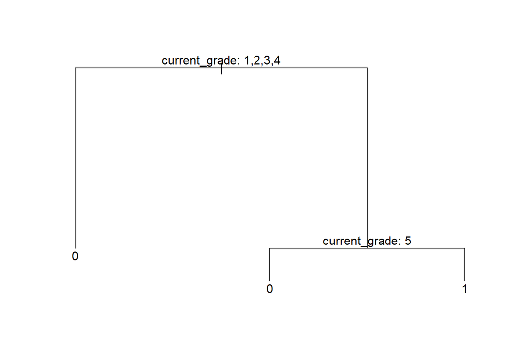

```r
plot(mrj_tree)
text(mrj_tree, pretty = 0)
```

```r
# predict on test
tree_pred <- predict(mrj_tree, newdata = test, type = "class")

# confusion matrix
table(Predicted = tree_pred, Actual = test$marijuana_ever_used)
```

```
##          Actual
## Predicted   0   1
##         0 263 116
##         1 247 383
```

```r
# accuracy
mean(tree_pred == test$marijuana_ever_used)
```

```
## [1] 0.6402379
```

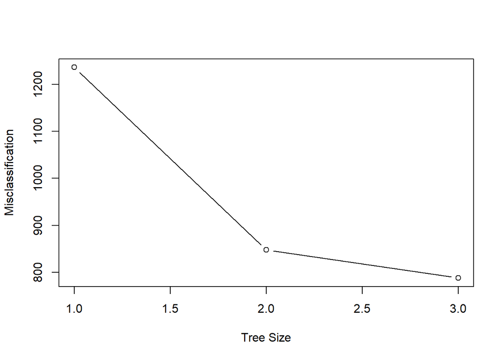

```r
### Prune Tree
set.seed(123)
cv_tree <- cv.tree(mrj_tree, FUN = prune.misclass)
plot(cv_tree$size, cv_tree$dev, type = "b", xlab = "Tree Size", ylab = "Misclassification")
```

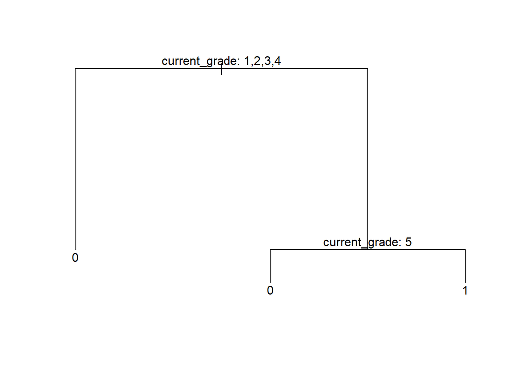

```r
# Prune to optimal size
best_size <- cv_tree$size[which.min(cv_tree$dev)]
pruned_tree <- prune.misclass(mrj_tree, best = best_size)

# Plot pruned tree
plot(pruned_tree)
text(pruned_tree, pretty = 0)
```

```r
# Predict again
pruned_pred <- predict(pruned_tree, test, type = "class")
mean(pruned_pred == test$marijuana_ever_used)
```

```
## [1] 0.6402379
```

```r
### Bagged Model
# train test split
set.seed(123)
train_idx <- sample(1:nrow(df_balanced), nrow(df_balanced)*0.7)
train <- df_balanced[train_idx, ]
test <- df_balanced[-train_idx, ]

# fit bagged model (max variables)
library(randomForest)
set.seed(123)
all_predictors <-  length(train)-1
bag_model <- randomForest(marijuana_ever_used~., data = train, mtry = all_predictors, importance = TRUE)
bag_model
```

```
##
## Call:
##  randomForest(formula = marijuana_ever_used ~ ., data = train,      mtry = all_predictors, importance = TRUE)
##                Type of random forest: classification
##                      Number of trees: 500
## No. of variables tried at each split: 7
##
##         OOB estimate of  error rate: 28.05%
## Confusion matrix:
##     0   1 class.error
## 0 827 354   0.2997460
## 1 306 866   0.2610922
```

```r
# fit bagged model (min variables)
library(randomForest)
set.seed(123)
all_predictors <-  length(train)-1
rf_model_min <- randomForest(marijuana_ever_used~., data = train, mtry = 1, importance = TRUE)
rf_model_min
```

```
##
## Call:
##  randomForest(formula = marijuana_ever_used ~ ., data = train,      mtry = 1, importance = TRUE)
##                Type of random forest: classification
##                      Number of trees: 500
## No. of variables tried at each split: 1
##
##         OOB estimate of  error rate: 32.04%
## Confusion matrix:
##     0   1 class.error
## 0 712 469   0.3971211
## 1 285 887   0.2431741
```

```r
### Random Forest (intermediate value)
# train test split
set.seed(123)
train_idx <- sample(1:nrow(df_balanced), nrow(df_balanced)*0.7)
train <- df_balanced[train_idx, ]
test <- df_balanced[-train_idx, ]

# fit random forest model
library(randomForest)
set.seed(123)
rf_model <- randomForest(marijuana_ever_used ~., data = train, mtry = 3, importance = TRUE)
rf_model
```

```
##
## Call:
##  randomForest(formula = marijuana_ever_used ~ ., data = train,      mtry = 3, importance = TRUE)
##                Type of random forest: classification
##                      Number of trees: 500
## No. of variables tried at each split: 3
##
##         OOB estimate of  error rate: 27.33%
## Confusion matrix:
##     0   1 class.error
## 0 810 371   0.3141406
## 1 272 900   0.2320819
```

```r
# importance
importance(rf_model)
```

```
##                              0         1 MeanDecreaseAccuracy MeanDecreaseGini
## sex                  14.081629  35.80397             36.33292         45.82017
## race_ethnicity       20.509405  47.54203             50.24107        128.46116
## self_reported_health 24.867325  68.94204             67.51596         95.12727
## current_grade        80.428923 115.19760            133.61245        260.79411
## household_income     23.926009  44.25535             49.86310         91.69738
## mother_in_household   8.562973  29.20813             27.27628         32.21623
## population_density   15.221625  35.10805             36.30770         72.61602
```

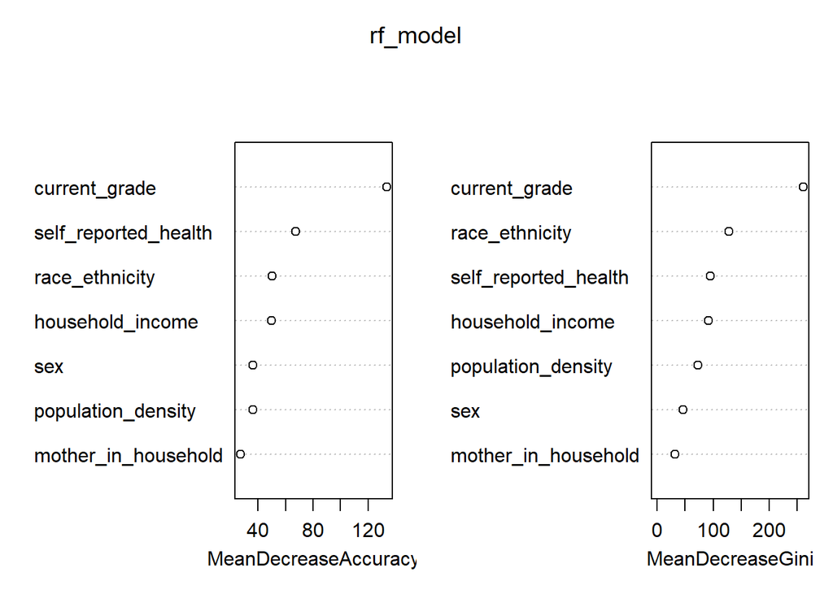

```r
varImpPlot(rf_model)
```

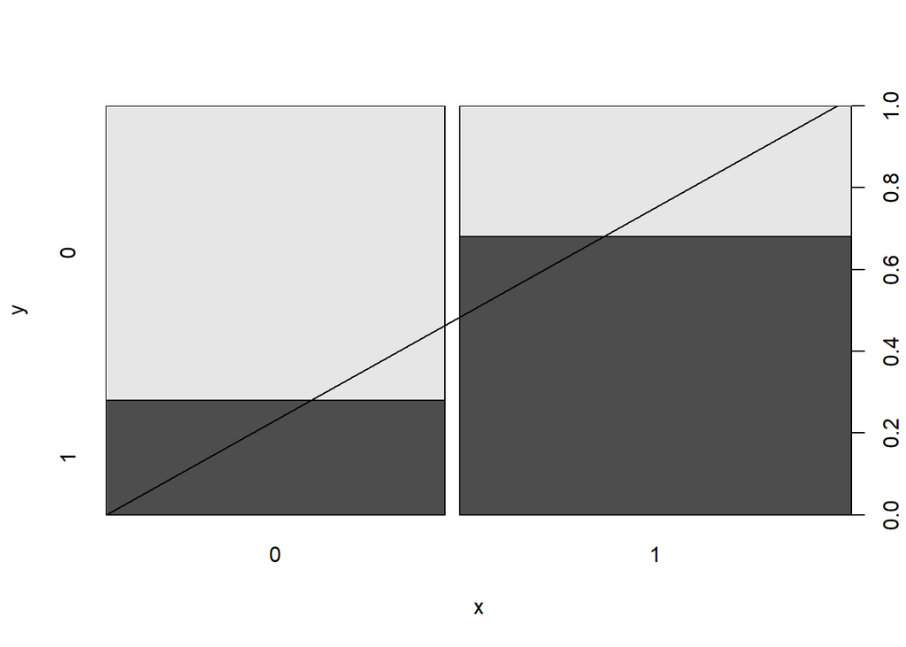

```r
# predict on test data
yhat.bag <- predict(rf_model, newdata = test)
plot(yhat.bag, test$marijuana_ever_used) # plot points
abline(0, 1) # plot regression line
```

```r
# accuracy
mean(yhat.bag == test$marijuana_ever_used)
```

```
## [1] 0.6987116
```

```r
# mse
mse <- mean((as.numeric(as.character(yhat.bag)) - as.numeric(as.character(test$marijuana_ever_used)))^2)
mse
```

```
## [1] 0.3012884
```

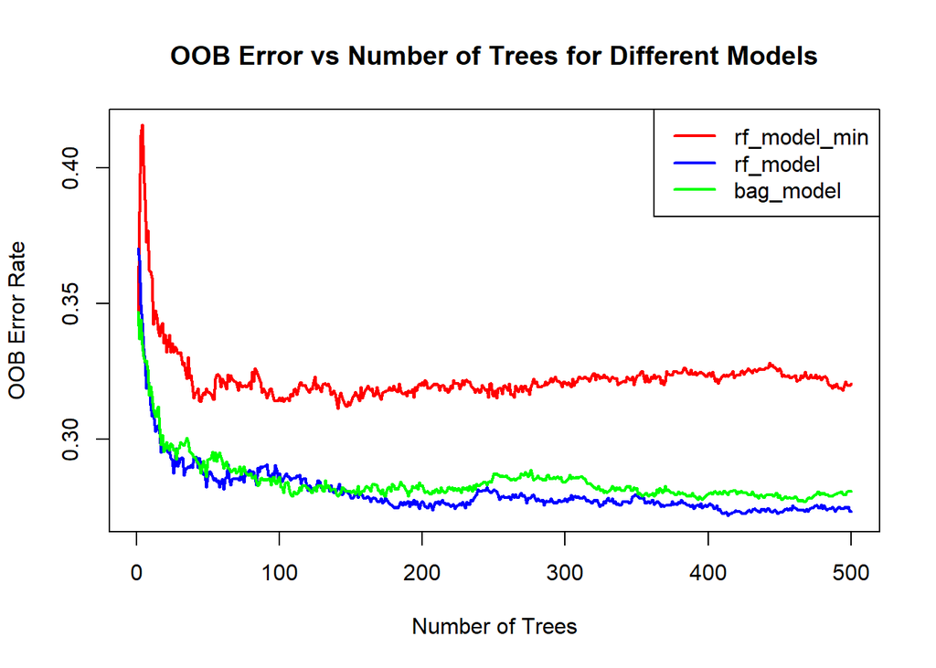

```r
### Comparing errors for different mtry values

# extract OOB errors for each model
oob_min <- rf_model_min$err.rate[, "OOB"]
oob_mid <- rf_model$err.rate[, "OOB"]
oob_bag <- bag_model$err.rate[, "OOB"]

# plot error vs number of trees
plot(oob_min, type = 'l', col = 'red', lwd = 2, xlab = 'Number of Trees', ylab = 'OOB Error Rate', main = 'OOB Error vs Number of Trees for Different Models', ylim = range(c(oob_min, oob_mid, oob_bag), na.rm = TRUE))

lines(oob_mid, col = 'blue', lwd = 2)
lines(oob_bag, col = 'green', lwd = 2)

legend("topright", legend = c("rf_model_min", "rf_model", "bag_model"),col = c("red", "blue", "green"), lwd = 2)
```

## Multi-Class: # days used marijuana in past month

Next, using a multi-class classification tree will help explore significant factors that are correlated with the number of days marijuana was used by youths in the past month. We will again use variables that are carefully selected from each category including demographics, school engagement, socio-economic status, family structure, and geographic context, as to avoid strong correlations among predictors.

There is a large data imbalance in our target variable, where most youths are non-marijuana users or have not used marijuana in the past month (5). To account for the disparity in the data, under sampling will help reduce the number of category 5 variables to match the number of 1-4 data points, while keeping enough data points to implement models like classification trees (reference to documentation used for under sampling technique: [link](https://www.rdocumentation.org/packages/UBL/versions/0.0.9/topics/RandUnderClassif)). The final balanced data set includes 745 observations, with each category consisting of about 150 data points.

```r
### DATA CLEANING MRJMDAYS
# install libaries
library(tree)

# Define variables
vars <- c(
  'sex',                      # IRSEX
  'race_ethnicity',           # NEWRACE2
  'self_reported_health',     # HEALTH2
  'current_grade',            # EDUSCHGRD2
  'household_income',         # INCOME
  'mother_in_household',      # IMOTHER
  'population_density',       # PDEN10
  'marijuana_days_past_month_cat'  # MRJMDAYS
)


# Subset and clean data
df_tree <- df %>%
  select(all_of(vars)) %>%
  drop_na() %>%
  mutate(marijuana_days_past_month_cat = as.factor(marijuana_days_past_month_cat))

# Data Imbalance
table(df_tree$marijuana_days_past_month_cat)
```

```
##
##    1    2    3    4    5
##  195  149  199  209 9796
```

```r
  # 1: 1-2 Days
  # 2: 3-5 Days
  # 3: 6-19 Days
  # 4: 20-30 Days
  # 5: Non user or not in past month
  # *** majority of youth falls under 5 category

# undersample the majority class (5)
library(UBL)
set.seed(123)
df_balanced <- RandUnderClassif(marijuana_days_past_month_cat ~ ., df_tree)
table(df_balanced$marijuana_days_past_month_cat)
```

```
##
##   1   2   3   4   5
## 149 149 149 149 149
```

The following code fits a multi-class classification tree that predicts the number of days youths have used marijuana in the past month, using the specified predictor variables from before. The balanced data is split into a 70% training set that the model is fit to and a 30% test set where predictions are used to test the accuracy of the model.

```r
### MULTI CLASSIFICATION: MRJMDAYS
# train test split (70/30)
set.seed(123)
train_idx <- sample(1:nrow(df_balanced), nrow(df_balanced)*0.7)
train <- df_balanced[train_idx, ]
test <- df_balanced[-train_idx, ]

table(train$marijuana_days_past_month_cat)
```

```
##
##   1   2   3   4   5
## 108 101 105 100 107
```

```r
table(test$marijuana_days_past_month_cat)
```

```
##
##  1  2  3  4  5
## 41 48 44 49 42
```

```r
# Fit classification tree
set.seed(123)
mrj_tree <- tree(marijuana_days_past_month_cat ~ ., data = train)

# Print and plot the tree
summary(mrj_tree)
```

```
##
## Classification tree:
## tree(formula = marijuana_days_past_month_cat ~ ., data = train)
## Variables actually used in tree construction:
## [1] "current_grade"
## Number of terminal nodes:  2
## Residual mean deviance:  3.102 = 1610 / 519
## Misclassification error rate: 0.7428 = 387 / 521
```

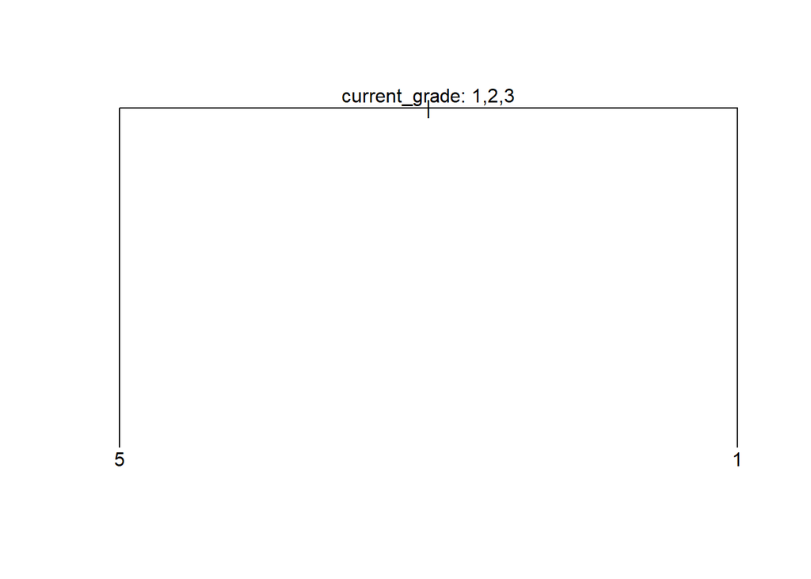

```r
plot(mrj_tree)
text(mrj_tree, pretty = 0)
```

```r
# predict on test
tree_pred <- predict(mrj_tree, newdata = test, type = "class")

# confusion matrix
table(Predicted = tree_pred, Actual = test$marijuana_days_past_month_cat)
```

```
##          Actual
## Predicted  1  2  3  4  5
##         1 39 48 44 49 28
##         2  0  0  0  0  0
##         3  0  0  0  0  0
##         4  0  0  0  0  0
##         5  2  0  0  0 14
```

```r
# accuracy
mean(tree_pred == test$marijuana_days_past_month_cat)
```

```
## [1] 0.2366071
```

After analyzing that most predictions were made for either classes 1 or 5, re-framing the problem might help improve the predictive power of classification trees. Collapsing the categorizes into fewer and more balanced classes, like never used marijuana, occasional use, and frequent use, can help the model pick up more nuances of the data.

To further improve predictions beyond a simple muti-class classification tree, we might consider ensemble methods that can take multiple classification trees and aggregate their solutions to produce a more robust prediction. In this specific case, a random forest or bagging methods would be helpful in reducing variance of the current model by creating many classification trees using random sampling with replacement, while also limiting the number of variables at each split so our model captures of the nuances in the data. We tested three models, a bagging model testing all predictors at each split, a random forest model testing 3 variables at each split, and a random forest model testing the minimum variable at each split.

After graphing the errors, we found that the random forest model testing the minimum number of variables has the lowest error and uses less computational power. The following code utilizes the random forest method on a balanced data set to predict the frequency of marijuana use based on the same predictor variables.

Variable importance of the random forest model will highlight demographic or socio-economic factors that may impact the frequency of youth marijuana use. Similarly to the binary classification model, grade level and student health are important factors that determine frequent use. This could be important to highlight in awareness classes that just because drug use may seem more prevalent in higher grades, does not mean giving into peer pressure is the right path forward. Also highlighting the importance of health, not just for high risk students, but also any potential risks that might occur with frequent drug use.

```r
### Random Forest
# regrouping data
df <- df %>%
  mutate(MRJMDAYS_CAT = case_when(
    marijuana_days_past_month_cat == 5 ~ "Never",
    marijuana_days_past_month_cat %in% c(1, 2) ~ "Occasional",
    marijuana_days_past_month_cat %in% c(3, 4) ~ "Frequent"
  )) %>%
  mutate(MRJMDAYS_CAT = factor(MRJMDAYS_CAT))
table(df$MRJMDAYS_CAT)
```

```
##
##   Frequent      Never Occasional
##        408       9809        344
```

```r
# Define variables
vars <- c(
  'sex',                           # IRSEX
  'race_ethnicity',               # NEWRACE2
  'self_reported_health',         # HEALTH2
  'current_grade',                # EDUSCHGRD2
  'household_income',             # INCOME
  'mother_in_household',          # IMOTHER
  'population_density',           # PDEN10
 'MRJMDAYS_CAT')

# Subset and clean data
df_tree <- df %>%
  select(all_of(vars)) %>%
  drop_na() %>%
  mutate(MRJMDAYS_CAT = as.factor(MRJMDAYS_CAT))

# balance data
set.seed(123)
df_balanced <- RandUnderClassif(MRJMDAYS_CAT ~ ., df_tree)
table(df_balanced$MRJMDAYS_CAT)
```

```
##
##   Frequent      Never Occasional
##        344        344        344
```

```r
# train test split
set.seed(123)
train_idx <- sample(1:nrow(df_balanced), nrow(df_balanced)*0.7)
train <- df_balanced[train_idx, ]
test <- df_balanced[-train_idx, ]

# fit random forest model
set.seed(123)
rf_model <- randomForest(MRJMDAYS_CAT ~., data = df_balanced[train_idx,], mtry = 3, importance = TRUE)
rf_model
```

```
##
## Call:
##  randomForest(formula = MRJMDAYS_CAT ~ ., data = df_balanced[train_idx,      ], mtry = 3, importance = TRUE)
##                Type of random forest: classification
##                      Number of trees: 500
## No. of variables tried at each split: 3
##
##         OOB estimate of  error rate: 55.82%
## Confusion matrix:
##            Frequent Never Occasional class.error
## Frequent         88    39        106   0.6223176
## Never            56   128         59   0.4732510
## Occasional       92    51        103   0.5813008
```

```r
# fit random forest model (minimum variables)
set.seed(123)
rf_model_min <- randomForest(MRJMDAYS_CAT ~., data = df_balanced[train_idx,], mtry = 1, importance = TRUE)
rf_model_min
```

```
##
## Call:
##  randomForest(formula = MRJMDAYS_CAT ~ ., data = df_balanced[train_idx,      ], mtry = 1, importance = TRUE)
##                Type of random forest: classification
##                      Number of trees: 500
## No. of variables tried at each split: 1
##
##         OOB estimate of  error rate: 54.99%
## Confusion matrix:
##            Frequent Never Occasional class.error
## Frequent         72    43        118   0.6909871
## Never            25   135         83   0.4444444
## Occasional       64    64        118   0.5203252
```

```r
# fit random forest model (maximum variables)
all_predictors <-  length(train)-1
set.seed(123)
bag_model <- randomForest(MRJMDAYS_CAT ~., data = df_balanced[train_idx,], mtry = all_predictors, importance = TRUE)
bag_model
```

```
##
## Call:
##  randomForest(formula = MRJMDAYS_CAT ~ ., data = df_balanced[train_idx,      ], mtry = all_predictors, importance = TRUE)
##                Type of random forest: classification
##                      Number of trees: 500
## No. of variables tried at each split: 7
##
##         OOB estimate of  error rate: 55.4%
## Confusion matrix:
##            Frequent Never Occasional class.error
## Frequent         97    44         92   0.5836910
## Never            53   128         62   0.4732510
## Occasional       98    51         97   0.6056911
```

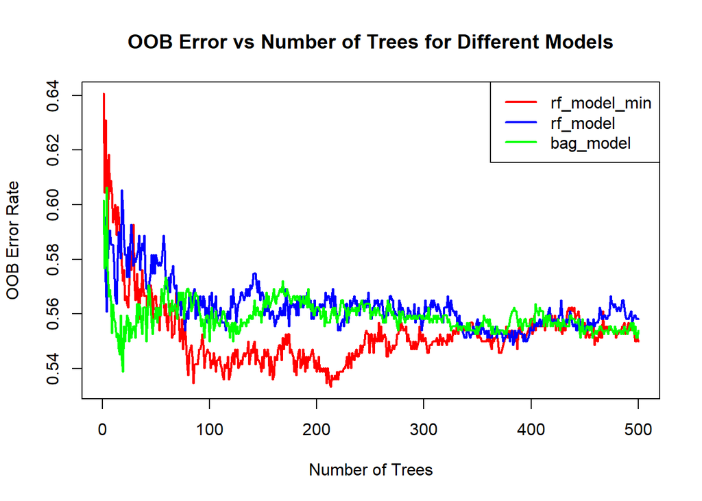

```r
### Comparing errors for different mtry values

# extract OOB errors for each model
oob_min <- rf_model_min$err.rate[, "OOB"]
oob_mid <- rf_model$err.rate[, "OOB"]
oob_bag <- bag_model$err.rate[, "OOB"]

# plot error vs number of trees
plot(oob_min, type = 'l', col = 'red', lwd = 2, xlab = 'Number of Trees', ylab = 'OOB Error Rate', main = 'OOB Error vs Number of Trees for Different Models', ylim = range(c(oob_min, oob_mid, oob_bag), na.rm = TRUE))

lines(oob_mid, col = 'blue', lwd = 2)
lines(oob_bag, col = 'green', lwd = 2)

legend("topright", legend = c("rf_model_min", "rf_model", "bag_model"),col = c("red", "blue", "green"), lwd = 2)
```